# Project Personal Finance

Team 1: Gia Huy, Hong Thu, Tuan Kiet, Phuong Duy

2023-08-05

# Problem

Tony is a recent graduate who wants to pursue a master’s degree but doesn’t have enough money. He decides to borrow $300,000 from Direct Plus with a 7.08% annual interest rate, compounded monthly. After graduation, Tony begins repaying the loan with a starting salary of $100,000 per year, increasing by 4% each year. With living expenses averaging $32,000 per year, Tony has $68,000 per year left to repay the loan, equating to $5,667 per month. Assuming a discount rate of 1.5% per year, Tony considers three repayment plans:

1. **Option 1 (Max repayment to clear debt quickly):** Pay 30% of his post-living expense income monthly until the debt is cleared. Total payment: $519,440 over 239 months.
2. **Option 2 (Minimum repayment to manage risk):** Pay 10% of his post-living expense income monthly for 25 years. The government forgives the remaining debt, but Tony pays 40% tax on the forgiven amount. Total payment: $527,666 over 25 years.
3. **Option 3 (Hybrid):** Follow Option 1 for 102 months, then switch to Option 2 for the remaining 198 months. The government forgives the remaining debt, but Tony pays 40% tax on the forgiven amount. Total payment: $493,168 over 25 years.

Finally, Tony chooses Option 3 to balance cost and risk. But how does Tony calculate these payments, and how does he know 102 months is the optimal switch point?

# First Option

```r
A <- 1 + 0.0708/12
B <- 1.04^{1/12}
C <- 1.015^{1/12}
x_1 <- c(0:239)
y <- round(300000*A^x_1 - 1700*(A^x_1 - B^x_1)/(A - B), 2)
y_1 <- round(1700/C*((B/C)^x_1-1)/((B/C)-1),2)
monthly_repayment <- round(1700*B^{x_1-1},2)
monthly_repayment[1]=0
monthly_repayment[240]=0
discounted_monthly_repayment <- round(1700/C*(B/C)^{x_1-1},2)
discounted_monthly_repayment[1]=0
discounted_monthly_repayment[240]=0
y[240]=0
y_1[240] <- round(y_1[239] + A*y[239],2)

first_option_df <- data.frame(x_1, y, monthly_repayment, discounted_monthly_repayment, y_1)
names(first_option_df) <- c("Month", "Loan remaining", "Monthly repayment", "Discounted monthly repayment","Total paid money")
first_option_df %>% datatable()
```

|  | Month | Loan remaining | Monthly repayment | Discounted monthly repayment | Total paid money |
| --- | --- | --- | --- | --- | --- |
| 1 | 0 | 300000 | 0 | 0 | 0 |
| 2 | 1 | 300070 | 1700 | 1697.89 | 1697.89 |
| 3 | 2 | 300134.85 | 1705.57 | 1701.34 | 3399.23 |
| 4 | 3 | 300194.49 | 1711.15 | 1704.79 | 5104.02 |
| 5 | 4 | 300248.89 | 1716.75 | 1708.25 | 6812.27 |
| 6 | 5 | 300297.99 | 1722.37 | 1711.72 | 8523.99 |
| 7 | 6 | 300341.74 | 1728.01 | 1715.19 | 10239.19 |
| 8 | 7 | 300380.09 | 1733.67 | 1718.67 | 11957.86 |
| 9 | 8 | 300412.99 | 1739.34 | 1722.16 | 13680.02 |
| 10 | 9 | 300440.39 | 1745.04 | 1725.66 | 15405.68 |

[output cut: 230 more lines]

## Loans after months

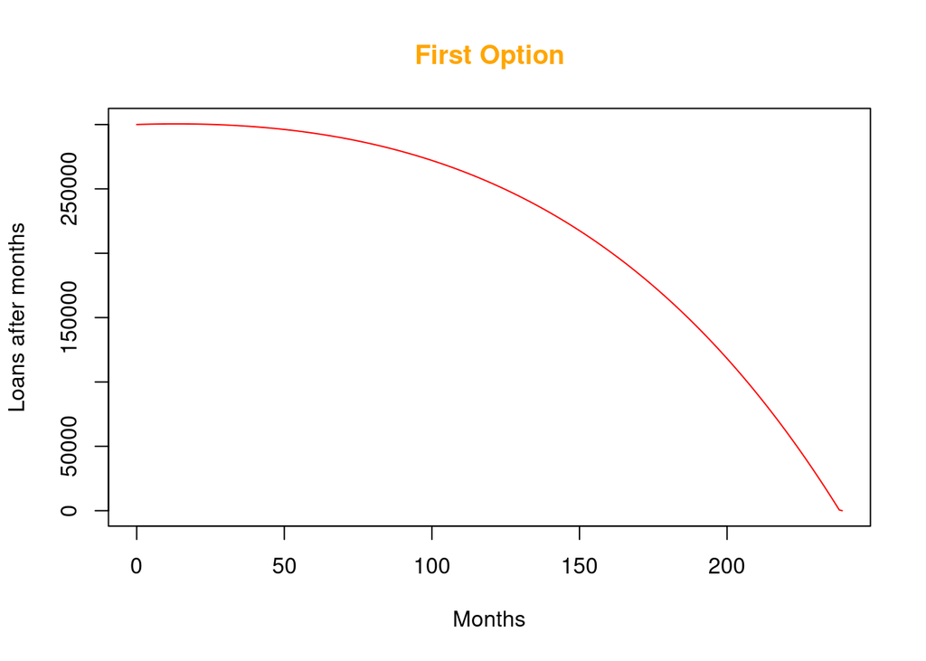

```r
plot(x_1, y[!y < 0], main = "First Option", col.main="orange", xlab="Months", ylab="Loans after months", type = "l", col ="red")
```

## Total paid money after months

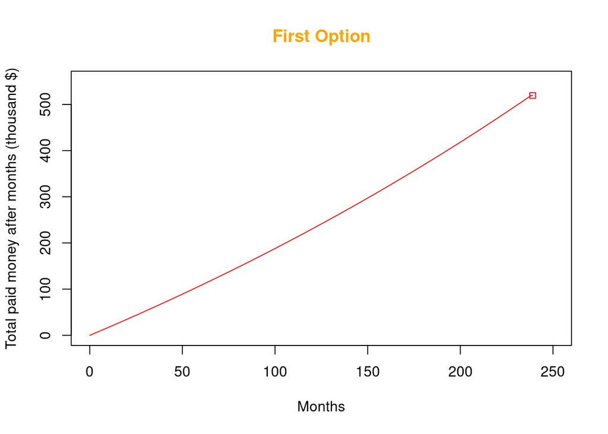

```r
plot(x_1, y_1/1000, main ="First Option", col.main="orange", xlab = "Months", ylab="Total paid money after months (thousand $)", xlim = c(0,250), ylim = c(0,550), type ="l", col="red",las = 0)
points(x_1[length(x_1)], y_1[length(y_1)]/1000, pch = 22, col = "red")
```

```r
(Total_Paid_Money_Option_1 <- first_option_df$`Total paid money`[240])
```

```
## [1] 519440
```

# Second Option

```r
x_2 <- c(0:300)
y_2 <- round(300*A^x_2 - 1.7/3*(A^x_2-B^x_2)/(A-B),2)
y_3 <- round(1.7/(3*C)*((B/C)^x_2-1)/((B/C)-1),2)
monthly_repayment_2 <- round(1.7/3*B^{x_2-1},2)
monthly_repayment_2[1]=0
discounted_monthly_repayment_2 <- round(1.7/C/3*(B/C)^{x_2-1},2)
discounted_monthly_repayment_2[1]=0


second_option_df <- data.frame(x_2, y_2, monthly_repayment_2, discounted_monthly_repayment_2, y_3)
names(second_option_df) <- c("Month", "Loan remaining", "Monthly repayment", "Discounted monthly repayment","Total paid Money")
second_option_df %>% datatable()
```

|  | Month | Loan remaining | Monthly repayment | Discounted monthly repayment | Total paid Money |
| --- | --- | --- | --- | --- | --- |
| 1 | 0 | 300 | 0 | 0 | 0 |
| 2 | 1 | 301.2 | 0.57 | 0.57 | 0.57 |
| 3 | 2 | 302.41 | 0.57 | 0.57 | 1.13 |
| 4 | 3 | 303.63 | 0.57 | 0.57 | 1.7 |
| 5 | 4 | 304.84 | 0.57 | 0.57 | 2.27 |
| 6 | 5 | 306.07 | 0.57 | 0.57 | 2.84 |
| 7 | 6 | 307.3 | 0.58 | 0.57 | 3.41 |
| 8 | 7 | 308.53 | 0.58 | 0.57 | 3.99 |
| 9 | 8 | 309.77 | 0.58 | 0.57 | 4.56 |
| 10 | 9 | 311.02 | 0.58 | 0.58 | 5.14 |

[output cut: 291 more lines]

## Loans after months

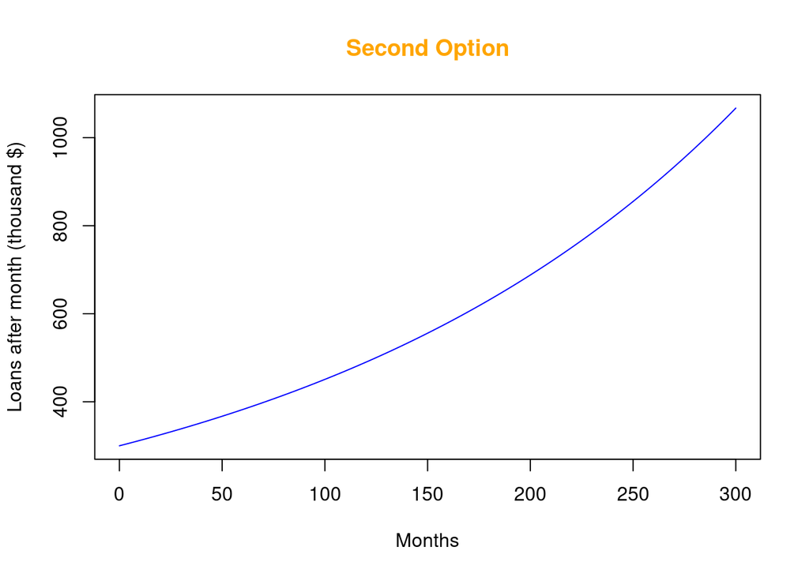

```r
plot(x_2, y_2, main = "Second Option", col.main="orange", xlab = "Months", ylab = "Loans after month (thousand $)", type = "l", las = 0, col = "blue")
```

### Total paid money

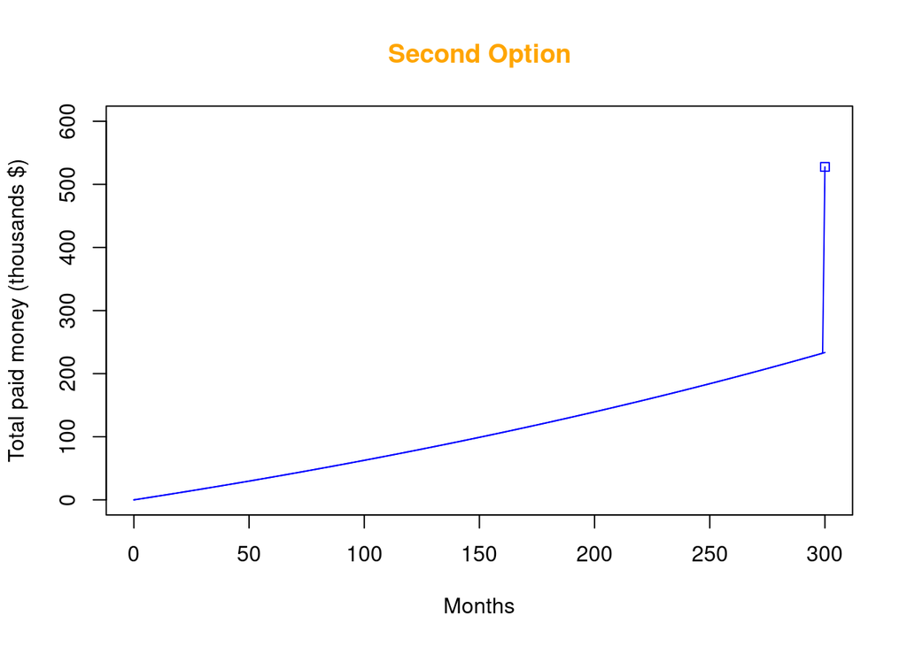

```r
plot(x_2, y_3, main="Second Option", col.main="orange", xlab = "Months", ylab = "Total paid money (thousands $)", ylim = c(0,600), type = "l", las = 0, col = "blue")
y_4 <- y_3
y_4[301]=y_3[301]+y_2[301]*0.4/(C^300)
lines(x_2, y_4, col = "blue")
points(x_2[301], y_4[301],pch = 22, col = "blue")
```

```r
y_4[301]
```

```
## [1] 527.6644
```

## Comparing First Option and Second Option’s total cummulative money paid:

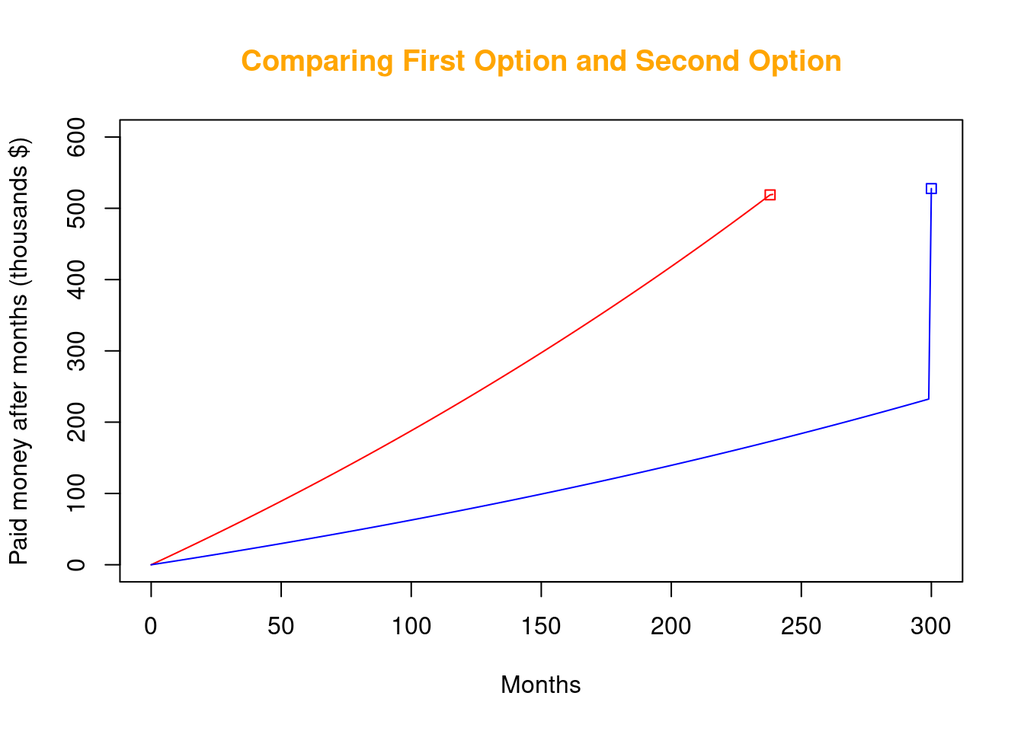

```r
plot(x_1, y_1/1000, main= "Comparing First Option and Second Option", col.main = "orange",xlab = "Months", ylab="Paid money after months (thousands $)", ylim= c(0,600), xlim = c(0,300), type ="l", col="red", las = 0)
points(x_1[239], y_1[239]/1000,pch = 22, col = "red")
lines(x_2, y_4, col = "blue")
points(x_2[301], y_4[301],pch = 22, col = "blue")
```

# Third Option: A hybrid between First and Second Option

## Find critical horizon

```r
X_3 <- c(0:210)
Y_3 <- 0.4/C^{300}*(300000*A^{300} - 1700*(A^{X_3}-B^{X_3})*A^{300 - X_3}/(A-B) - 1700 * B^{X_3}* (A^{300 - X_3} - B^{300 - X_3})/(3*A-3*B))
Y_4 <- 1700*((B/C)^{X_3} - 1)/(B - C) + 1700*(B/C)^{X_3}*((B/C)^{300-X_3} - 1)/(3*B - 3*C)
Y_5 <- Y_3 + Y_4
Y_5
```

```
##   [1] 527666.1 526984.0 526308.9 525640.8 524979.7 524325.7 523678.6 523038.6
##   [9] 522405.5 521779.4 521160.3 520548.2 519943.0 519344.7 518753.5 518169.1
##  [17] 517591.7 517021.2 516457.6 515900.9 515351.1 514808.2 514272.2 513743.1
##  [25] 513220.9 512705.5 512197.0 511695.3 511200.5 510712.6 510231.4 509757.1
##  [33] 509289.6 508828.9 508375.1 507928.0 507487.7 507054.2 506627.5 506207.6
##  [41] 505794.5 505388.1 504988.4 504595.5 504209.4 503830.0 503457.3 503091.4
##  [49] 502732.2 502379.7 502033.9 501694.8 501362.4 501036.7 500717.7 500405.4
##  [57] 500099.8 499800.8 499508.5 499222.8 498943.8 498671.5 498405.8 498146.7
##  [65] 497894.3 497648.4 497409.3 497176.7 496950.7 496731.4 496518.6 496312.5
##  [73] 496112.9 495920.0 495733.6 495553.8 495380.5 495213.9 495053.7 494900.2
##  [81] 494753.2 494612.8 494478.9 494351.5 494230.7 494116.4 494008.6 493907.4
##  [89] 493812.6 493724.4 493642.7 493567.5 493498.8 493436.6 493380.9 493331.7
##  [97] 493288.9 493252.7 493222.9 493199.6 493182.8 493172.4 493168.5 493171.0
## [105] 493180.0 493195.4 493217.3 493245.7 493280.4 493321.6 493369.3 493423.3
## [113] 493483.8 493550.7 493624.1 493703.8 493790.0 493882.5 493981.5 494086.8
## [121] 494198.6 494316.7 494441.3 494572.2 494709.5 494853.3 495003.3 495159.8
## [129] 495322.6 495491.8 495667.4 495849.3 496037.6 496232.3 496433.3 496640.7
## [137] 496854.4 497074.4 497300.9 497533.6 497772.7 498018.1 498269.9 498528.0
## [145] 498792.5 499063.2 499340.3 499623.7 499913.5 500209.5 500511.9 500820.6
## [153] 501135.6 501456.9 501784.6 502118.5 502458.8 502805.3 503158.2 503517.3
## [161] 503882.8 504254.5 504632.6 505016.9 505407.5 505804.5 506207.7 506617.2
## [169] 507033.0 507455.0 507883.4 508318.0 508758.9 509206.1 509659.6 510119.3
## [177] 510585.3 511057.6 511536.2 512021.0 512512.1 513009.5 513513.1 514023.1
## [185] 514539.2 515061.7 515590.4 516125.3 516666.6 517214.1 517767.8 518327.8
## [193] 518894.1 519466.6 520045.4 520630.5 521221.8 521819.3 522423.2 523033.2
## [201] 523649.6 524272.1 524901.0 525536.1 526177.4 526825.0 527478.9 528139.0
## [209] 528805.3 529477.9 530156.8
```

```r
(Critical_horizon <- which.min(Y_5)-1)
```

```
## [1] 102
```

## Total paid money

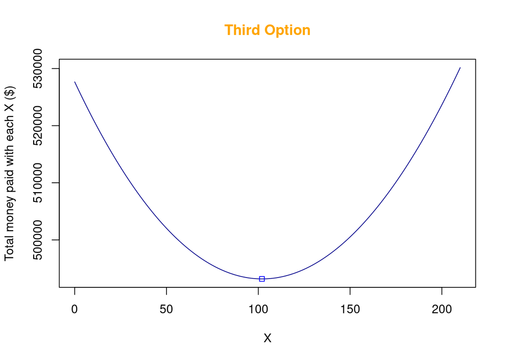

```r
plot(X_3, Y_5[0:length(X_3)], type = "l", main = "Third Option", col.main="orange", xlab = "X", ylab = "Total money paid with each X ($)", col = "darkblue")
points(X_3[103],Y_5[103], pch = 22, col = "blue")
```

```r
min(Y_5)
```

```
## [1] 493168.5
```

## Paid money per month

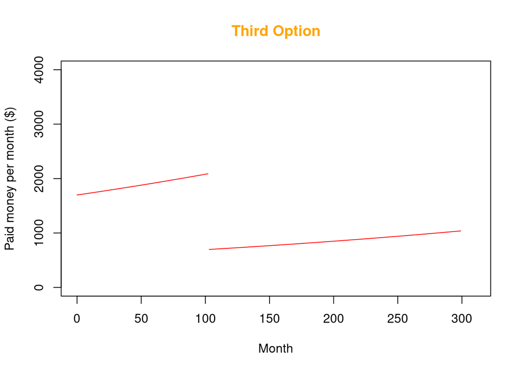

```r
const <- 0.4/C^{300}*(300000*A^{300} - 1700*(A^{102}-B^{102})*A^{300 - 102}/(A-B) - 1700 * B^{102}* (A^{300 - 102} - B^{300 - 102})/(3*A-3*B))
P_1 <- c(0:102)
P_2 <- c(103:300)
B_1 <- 1700/C*(B/C)^{P_1}
B_2 <- 1700*(B/C)^{102}/(3*C)*(B/C)^{P_2-102}
plot(P_1, B_1, main="Third Option", col.main="orange", xlab = "Month", ylab = "Paid money per month ($)", type = "l", col = "red", xlim = c(0,310), ylim = c(0,4000))
lines(P_2[1:(length(P_2) - 1)], B_2[1:(length(P_2)-1)], col = "red", type = "l")
```

## Applying SAVE PLAN

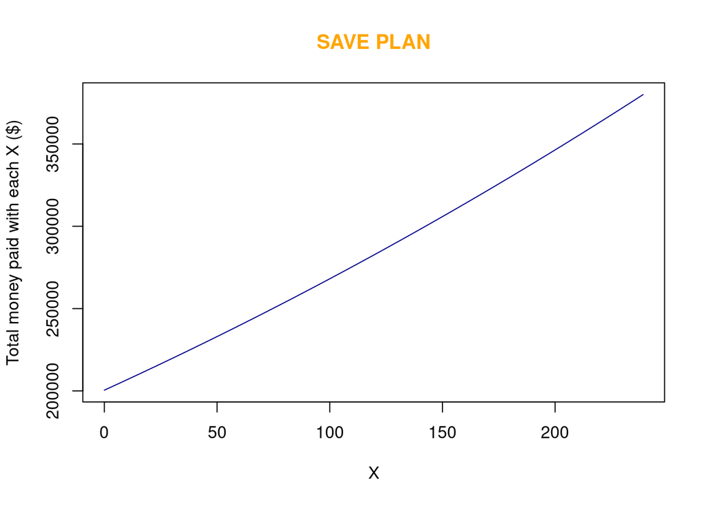

```r
m <- c(0:239)
T_1 <- 0.4/C^{300}*(300000 - 1300*(B^m - 1)/(B - 1) - 1300/3*B^m*(B^{300 - m} - 1)/(B - 1))
T_2 <- 1300/C*((B/C)^m - 1)/(B/C - 1)
T_3 <- 1300*(B/C)^m/(3*C)*((B/C)^{300-m} - 1)/(B/C - 1)
SAVE <- T_1 + T_2 + T_3

plot(m, SAVE, main="SAVE PLAN", col.main="orange", type = "l", xlab = "X", ylab = "Total money paid with each X ($)", col = "darkblue")
```

```r
min(SAVE)
```

```
## [1] 200454.6
```

```r
which.min(SAVE)-1
```

```
## [1] 0
```